# DSCI101 Homework 4

Lily Kraus

2023-03-16

Install mosaic data library

```r
library(tidyverse)
```

```r
library(mosaicData)
head(HELPrct[,1:5])
```

```
##   age anysubstatus anysub cesd d1
## 1  37            1    yes   49  3
## 2  37            1    yes   30 22
## 3  26            1    yes   39  0
## 4  39            1    yes   15  2
## 5  32            1    yes   39 12
## 6  47            1    yes    6  1
```

1a. Use the HELPrct data from the mosaicData to calculate the mean of all numeric variables (be sure to exclude missing values)

```r
HELPrct %>% summarize(across(where(is.numeric), mean, na.rm = TRUE))
```

```
##        age anysubstatus     cesd       d1 daysanysub dayslink drugrisk      e2b
## 1 35.65342    0.7723577 32.84768 3.059603   75.30738 255.6056 1.887168 2.504673
##      female       i1       i2       id   indtot linkstatus      mcs      pcs
## 1 0.2362031 17.90728 24.54746 233.4018 35.72848  0.3781903 31.67668 48.04854
##     pss_fr  sexrisk avg_drinks max_drinks hospitalizations
## 1 6.706402 4.642384   17.90728   24.54746         3.059603
```

1b. Find the mean of all the numeric variables stratified by sex and age group where age groups are defined as ranges of 10 years (i.e. 0-10,10-20, 20-30, etc).

```r
max_age = max(HELPrct$age)
#to get age ranges use seq(0,max_age,10)

#Apply age ranges to the data
HELPrct %>% mutate(age_group = cut(age,breaks = seq(0,max_age,by = 10))) %>% group_by(sex,age_group) %>% summarise(across(where(is.numeric), mean, na.rm = TRUE))
```

[output not shown]

```
## # A tibble: 9 × 23
## # Groups:   sex [2]
##   sex    age_gr…¹   age anysu…²  cesd    d1 daysa…³ daysl…⁴ drugr…⁵   e2b female
##   <fct>  <fct>    <dbl>   <dbl> <dbl> <dbl>   <dbl>   <dbl>   <dbl> <dbl>  <dbl>
## 1 female (20,30]   27.1   0.769  38.7  2.30    67.2    296.    2.52  2.5       1
## 2 female (30,40]   35.0   0.731  36.6  3.63    91.8    272.    1.54  1.76      1
## 3 female (40,50]   45.5   0.6    35.6  4.33    85.7    245.    1.71  2.17      1
## 4 female (50,60]   56.7   0.667  39.3  3       77      262.    0     1.5       1
## 5 male   (10,20]   19.7   1      38.7  1       98.5    264.    0     8         0
## 6 male   (20,30]   26.7   0.786  32.2  1.93    77.9    264.    3.02  2.16      0
## 7 male   (30,40]   35.1   0.789  30.6  2.57    73.6    245.    1.29  2.56      0
## 8 male   (40,50]   44.1   0.810  32.5  4.45    69.5    247.    2.18  3.03      0
## 9 male   (50,60]   55.4   0.75   34.3  6.31    45      262.    1.69  3.12      0
## # … with 12 more variables: i1 <dbl>, i2 <dbl>, id <dbl>, indtot <dbl>,
## #   linkstatus <dbl>, mcs <dbl>, pcs <dbl>, pss_fr <dbl>, sexrisk <dbl>,
## #   avg_drinks <dbl>, max_drinks <dbl>, hospitalizations <dbl>, and abbreviated
## #   variable names ¹age_group, ²anysubstatus, ³daysanysub, ⁴dayslink, ⁵drugrisk
```

1c. For 30 year olds, compute the average number of lifetime hospitalizations (variable d1). Now find which age has the average number of hospitalizations that is closest to the average number of hospitalizations for 30 year olds.

```r
#For 30 year olds
#Variable storing value for avg hospitalizations for 30 yr olds
hosp_30 <- HELPrct %>% filter(age == 30) %>% summarize(avg_visits = mean(d1, na.rm = TRUE)) %>% pull(avg_visits)

#Find which age has average number of hospitalizations closest to 30 year olds.
#Find the smallest difference between avg number of hospitalizations

HELPrct %>% group_by(age) %>% summarize(avg_visits = mean(d1, na.rm = TRUE)) %>% mutate(diff_30 = abs(hosp_30 - avg_visits)) %>% select(age,avg_visits,diff_30) %>% filter(age != 30) %>% arrange(diff_30) %>% head(1) %>% pull(age)
```

```
## [1] 36
## attr(,"label")
## [1] "age (years)"
```

```r
#For checking
avgs <- HELPrct %>% group_by(age) %>% summarize(avg_visits = mean(d1, na.rm = TRUE))
```

1d. Write a function that does what is asked in the previous question but for an arbitrary age. That is, age is the input to the function and that function will return the age that has the mean number of lifetime hospitalizations that is closest to the input age.

```r
find_closest_age <- function(input_age){

  input_avg <- HELPrct %>% filter(age == input_age) %>% summarize(avg_visits = mean(d1, na.rm = TRUE)) %>% pull(avg_visits)

  closest_age <- HELPrct %>% group_by(age) %>% summarize(avg_visits = mean(d1, na.rm = TRUE)) %>% mutate(avg_diff = abs(input_avg - avg_visits)) %>% select(age,avg_visits,avg_diff) %>% filter(age != input_age) %>% arrange(avg_diff) %>% head(1) %>% pull(age)

  return(data.frame(input_age,closest_age))
  #return(as.integer(output_age))

}

output_df <- find_closest_age(30)
find_closest_age(30)
```

```
##   input_age closest_age
## 1        30          36
```

1e. Using map, run this function for all ages 19 through 60 and plot the results (i.e. x-axis is input (19-60), y-axis is the result of the function).

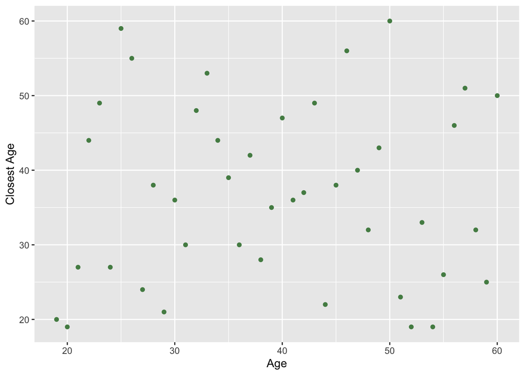

```r
years <- c(19:60)

results <- map_dfr(years,find_closest_age)
names(results) <- c("age","closest_age")

ggplot(data = results,aes(x=age,y=closest_age)) + geom_point(stat = "identity",col ="palegreen4") + xlab("Age") + ylab("Closest Age")
```

load Lahman library, use IDs corresponding to Brooklyn baseball teams from the Teams data frame.

```r
library(Lahman)
bk_teams <- c("BR1", "BR2", "BR3", "BR4", "BRO", "BRP", "BRF")
data(Teams)
head(Teams)[,1:5]
```

```
##   yearID lgID teamID franchID divID
## 1   1871   NA    BS1      BNA  <NA>
## 2   1871   NA    CH1      CNA  <NA>
## 3   1871   NA    CL1      CFC  <NA>
## 4   1871   NA    FW1      KEK  <NA>
## 5   1871   NA    NY2      NNA  <NA>
## 6   1871   NA    PH1      PNA  <NA>
```

2a. Use map int() to find the number of seasons in which each of those teams played by calling a function called count seasons

```r
#without function
#Teams %>% filter(teamID %in% bk_teams) %>% group_by(teamID) %>% summarise(num_seasons = n())

count_seasons <- function(teams){

  Teams %>% group_by(teamID) %>% filter(teamID %in% teams) %>% summarise(num_seasons = n())

}

season_results <- map_dfr(bk_teams,count_seasons)
map_dfr(bk_teams,count_seasons)
```

```
## # A tibble: 7 × 2
##   teamID num_seasons
##   <fct>        <int>
## 1 BR1              1
## 2 BR2              4
## 3 BR3              6
## 4 BR4              1
## 5 BRO             68
## 6 BRP              1
## 7 BRF              2
```

2b. Plot results using an appropriate data visualization

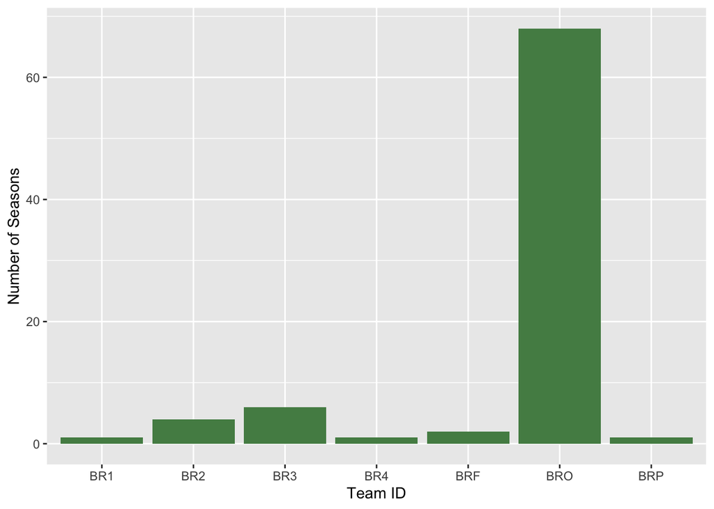

```r
ggplot(data = season_results,aes(x=as.factor(teamID),y=num_seasons)) + geom_bar(stat="identity",fill="palegreen4") + xlab("Team ID") + ylab("Number of Seasons")
```

2c. Write a function that takes the TeamID as input and returns two things: 1) the name of the team that hit the most homeruns in a season over the period that the input team existed and 2) the maximum number of home runs hit in a season over the time period where the input team existed. Using map, run this function across all the Brooklyn teams.

```r
library(purrr)
library(tidyverse)

get_most_HR <- function(inputID) {

  team_years <- Teams %>% filter(teamID == inputID) %>% pull(yearID)

  most_HR_team <- Teams %>% filter(yearID %in% team_years) %>% group_by(teamID,name,yearID) %>% summarize(tot_HR = sum(HR)) %>% arrange(-tot_HR) %>% head(1) %>% pull(name)

  most_HR <- Teams %>% filter(yearID %in% team_years) %>% group_by(yearID) %>% summarise(tot_HR = sum(HR)) %>% arrange(-tot_HR) %>% head(1) %>% pull(tot_HR)

  return(data.frame(inputID,most_HR_team,most_HR))

}

#HR_results <- map_dfr(bk_teams,get_most_HR)
map_dfr(bk_teams,get_most_HR)
```

```
##   inputID            most_HR_team most_HR
## 1     BR1      Baltimore Canaries      37
## 2     BR2    Boston Red Stockings      47
## 3     BR3 Chicago White Stockings     689
## 4     BR4           Chicago Colts     764
## 5     BRO      Cincinnati Redlegs    2294
## 6     BRP           Chicago Colts     764
## 7     BRF   Philadelphia Phillies     711
```

```r
#without function
team_years <- Teams %>% filter(teamID == "BR1") %>% pull(yearID)

most_HR_team <- Teams %>% filter(yearID %in% team_years) %>% group_by(teamID,name,yearID) %>% summarize(tot_HR = sum(HR)) %>% arrange(-tot_HR) %>% head(1) %>% pull(name)
most_HR <- Teams %>% filter(yearID %in% team_years) %>% group_by(yearID) %>% summarise(tot_HR = sum(HR)) %>% arrange(-tot_HR) %>% head(1) %>% pull(tot_HR)
```